# Applied Machine Learning in Python

## 0. 基本流程和工具

李航给出的机器学习定义是：计算机基于数据构建概率统计模型并运用模型对数据进行预测和分析的学科。

这里的模型是通用的，但是参数不是，对于不同数据有不同的参数。在很多方法，比如梯度下降和K-Means，都是通过不断的优化来得到最优参数，给定可能的一些值，给定评价标准，让机器选择最合适的参数，称之为学习。

机器学习的学习值得到底是：给定空白模型，不断优化得到最优模型的能力，还是得到最优模型后，通过不断的新数据，将过去的最优模型优化为更优模型的能力？我认为都说得通。

**Basic WorkFlow**:

[figure not shown]

很多时候会忽略第一步，但这非常重要，比如：

[figure not shown]

像是文本，一般使用 TF-IDF 来提取关键特征。对于图片等，可以使用 PCA 来降低维度加快计算。

[figure not shown]

**scikit-learn**

```
from sklearn.model_selection import train_test_split
from sklearn.tree import DecisionTreeClassifier
```

USER_GUIDE: `http://scikit-learn.org/stable/user_guide.html`

TOTORIAL `http://scikit-learn.org/stable/tutorial/index.html`

## 1. 应用机器学习：使用 `K-NN` 预测水果种类

### 1.1 加载数据，检查数据

```python
%matplotlib notebook
import numpy as np
import matplotlib.pyplot as plt
import pandas as pd
from sklearn.model_selection import train_test_split

fruits = pd.read_table('fruit_data_with_colors.txt')
```

```python
print (fruits.shape)
fruits.head()
```

```
(59, 7)
```

|  | fruit_label | fruit_name | fruit_subtype | mass | width | height | color_score |
| --- | --- | --- | --- | --- | --- | --- | --- |
| 0 | 1 | apple | granny_smith | 192 | 8.4 | 7.3 | 0.55 |
| 1 | 1 | apple | granny_smith | 180 | 8.0 | 6.8 | 0.59 |
| 2 | 1 | apple | granny_smith | 176 | 7.4 | 7.2 | 0.60 |
| 3 | 2 | mandarin | mandarin | 86 | 6.2 | 4.7 | 0.80 |
| 4 | 2 | mandarin | mandarin | 84 | 6.0 | 4.6 | 0.79 |

重量，宽度和高度以及颜色是每个水果的四种特征。

### 1.2 数据可视化

检查数据十分必要，因为有可能存在缺失数据或者单位问题，这对于后来的机器建模影响很大。使用pandas的条件查找以及可视化来帮助我们做到这一点。

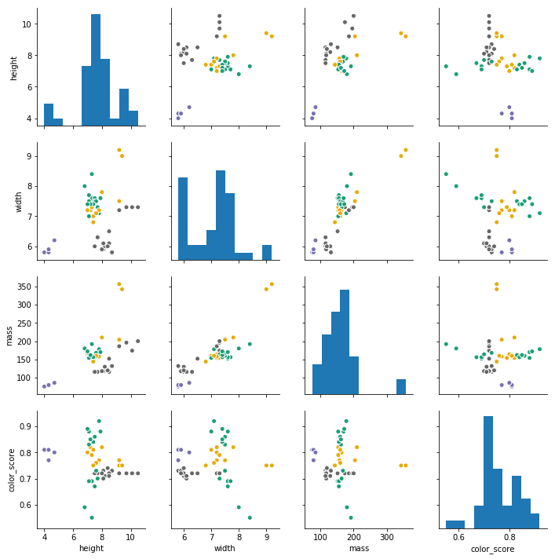

```python
import seaborn as sns
from matplotlib import cm
X = fruits[['height', 'width', 'mass', 'color_score']]
y = fruits['fruit_label']
X_train, X_test, y_train, y_test = train_test_split(X, y, random_state=0)
cmap = cm.get_cmap("Dark2")
c = cm.ScalarMappable(None,cmap)
c.set_array([])
sns.pairplot(X_train,plot_kws={"color":c.to_rgba(y_train)})
```

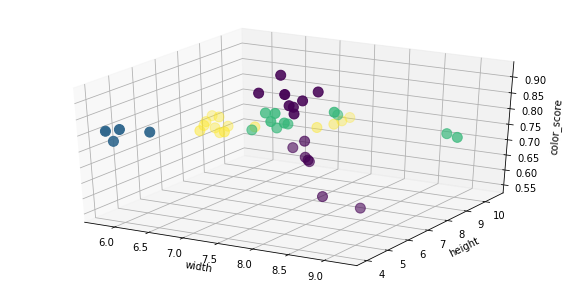

```python
# plotting a 3D scatter plot
from mpl_toolkits.mplot3d import Axes3D

fig = plt.figure(figsize=(10,5))
ax = fig.add_subplot(111, projection = '3d')
ax.scatter(X_train['width'], X_train['height'], X_train['color_score'], c = y_train, marker = 'o', s=100)
ax.set_xlabel('width')
ax.set_ylabel('height')
ax.set_zlabel('color_score')
plt.show()
```

### 1.3 构建KNN算法

`算法 >> 拟合(fit) >> 评估(score) >> 调整参数和特征 >> 重新拟合 >> ... >> 预测(predict)`

```python
# 选择特征，随机化分组
X = fruits[['mass', 'width', 'height']]
y = fruits['fruit_label']

# 默认 0.75 0.25
X_train, X_test, y_train, y_test = train_test_split(X, y, random_state=0, test_size=0.2)
```

```python
# 使用KNN算法进行分类，选择邻居为5的为一类
from sklearn.neighbors import KNeighborsClassifier
knn = KNeighborsClassifier(n_neighbors = 5)
```

```python
# 之后使用fit拟合数据
knn.fit(X_train, y_train)
```

```
KNeighborsClassifier(algorithm='auto', leaf_size=30, metric='minkowski',
           metric_params=None, n_jobs=1, n_neighbors=5, p=2,
           weights='uniform')
```

```python
# 进行测试集评估
print("测试集合的准确性为：%.5f"%knn.score(X_test, y_test))
```

[output not shown]

```python
# 用来对新数据进行预测
fruit_prediction = knn.predict([[20, 4.3, 5.5]])#输出的是被预测的变量——label
print("水果是 %s"%lookup_fruit_name[fruit_prediction[0]])
```

```
水果是 mandarin
```

### 1.4 一些有趣的探索：邻居

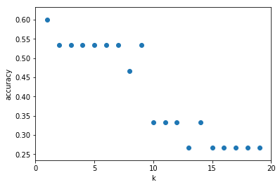

```python
k_range = range(1,20)
scores = []

for k in k_range:
    knn = KNeighborsClassifier(n_neighbors = k)
    knn.fit(X_train, y_train)
    scores.append(knn.score(X_test, y_test))

plt.figure()
plt.xlabel('k')
plt.ylabel('accuracy')
plt.scatter(k_range, scores)
plt.xticks([0,5,10,15,20]);
```

[figure not shown]

KNN原理是，将空间中任意点看作一个cell，然后将共同被标记为同一类的点看作是此类的范围。K的意思是，在进行类的划分的时候(比如说，对于一个新的值)，使用K个临近点（欧几里得距离到这个点最小的k个邻居们）的类别，通过多数表决的方式进行预测。

对于较小的K值，具有较大的估计误差以及较小的近似误差，只有当新的点很接近这些老点的时候，才能精准预测。换句话说，过拟合。

对于较大的K值，具有较大的近似误差和较小的估计误差，这是典型的拟合不足。对于接近总个数的K的选择，会使用所有的点来进行决策，这导致了必定会被分配到占据优势地位的类中去。

### 1.5 一些有趣的探索：数据拆分

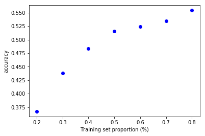

```python
t = [0.8, 0.7, 0.6, 0.5, 0.4, 0.3, 0.2]

knn = KNeighborsClassifier(n_neighbors = 5)

plt.figure()

for s in t:

    scores = []
    for i in range(1,1000):
        X_train, X_test, y_train, y_test = train_test_split(X, y, test_size = 1-s)
        knn.fit(X_train, y_train)
        scores.append(knn.score(X_test, y_test))
    plt.plot(s, np.mean(scores), 'bo')

plt.xlabel('Training set proportion (%)')
plt.ylabel('accuracy');
```